# Urban Air Quality And Health Impact Analysis EDA Project 1 - Team 2

Abilasha Singh, Aswin Balaji Thippa Ramesh, Lixing Pan

Research Summary  
1. Introduction

Rising concerns about urban air quality and its impact on public health have prompted researchers to investigate the intricate links between environmental factors and health outcomes. This report provides a thorough analysis of how weather conditions relate to health risk scores in different cities during September. To achieve this, we began by developing several SMART questions focused on understanding how factors like temperature, humidity, and wind speed affect health risk scores. To reach our goals, we performed a detailed exploratory data analysis (EDA) to uncover patterns and trends in the dataset. We also used appropriate statistical tests to validate our findings and draw meaningful conclusions. This report aims to clarify the connections between environmental conditions and health.

2. Dataset Summary

2.1 Dataset Overview

Data Loading

```
##     datetime datetimeEpoch tempmax tempmin temp feelslikemax feelslikemin
## 1 07-09-2024    1725692400    89.0    62.1 73.3         88.6         62.1
## 2 08-09-2024    1725778800    89.0    60.0 72.4         87.9         60.0
## 3 10-09-2024    1725951600    79.4    59.6 67.8         79.4         59.6
## 4 11-09-2024    1726038000    77.3    57.6 66.3         77.3         57.6
## 5 12-09-2024    1726124400    79.2    57.8 67.4         79.2         57.8
## 6 13-09-2024    1726210800    83.2    58.9 69.6         82.2         58.9
##   feelslike  dew humidity precip precipprob precipcover snow snowdepth windgust
## 1      73.3 59.8     66.3      0          0           0    0         0     16.1
## 2      72.3 57.6     62.5      0          0           0    0         0     13.9
## 3      67.8 57.2     70.7      0          0           0    0         0     17.4
## 4      66.3 56.8     73.1      0          4           0    0         0     23.0
## 5      67.4 55.6     68.3      0          5           0    0         0     17.9
## 6      69.5 54.2     60.5      0          0           0    0         0     16.1
##   windspeed winddir pressure cloudcover visibility solarradiation solarenergy
```

[output cut: 34 more lines]

Data Description and Summmary

```
## [1] "Row Count: 27674 Column Count: 43"
```

```
## 'data.frame':    27674 obs. of  43 variables:
##  $ datetime         : chr  "07-09-2024" "08-09-2024" "10-09-2024" "11-09-2024" ...
##  $ datetimeEpoch    : num  1725692400 1725778800 1725951600 1726038000 1726124400 ...
##  $ tempmax          : num  89 89 79.4 77.3 79.2 83.2 81.4 78.3 81.2 82.3 ...
##  $ tempmin          : num  62.1 60 59.6 57.6 57.8 58.9 59.4 59.8 59.3 60.9 ...
##  $ temp             : num  73.3 72.4 67.8 66.3 67.4 69.6 68.8 66.8 68.9 68.5 ...
##  $ feelslikemax     : num  88.6 87.9 79.4 77.3 79.2 82.2 81.3 78.3 79.6 80.2 ...
##  $ feelslikemin     : num  62.1 60 59.6 57.6 57.8 58.9 59.4 59.8 59.3 60.9 ...
##  $ feelslike        : num  73.3 72.3 67.8 66.3 67.4 69.5 68.8 66.8 68.6 68.4 ...
##  $ dew              : num  59.8 57.6 57.2 56.8 55.6 54.2 55.5 47.3 44.4 46.6 ...
##  $ humidity         : num  66.3 62.5 70.7 73.1 68.3 60.5 64.2 52.9 43.5 47.6 ...
##  $ precip           : num  0 0 0 0 0 0 0 0 0 0 ...
##  $ precipprob       : num  0 0 0 4 5 0 1 3.2 0 0 ...
##  $ precipcover      : num  0 0 0 0 0 0 0 0 0 0 ...
##  $ snow             : int  0 0 0 0 0 0 0 0 0 0 ...
```

[output cut: 29 more lines]

2.2 Data Source

The dataset is presumed to originate from a weather forecasting or environmental aggregation service and is sourced from the Kaggle website.

2.3 Scope and SMART Questions

Key variables such as temperature, humidity, wind speed, visibility, and weather descriptions facilitate a comprehensive analysis of the effects of urban air quality on health. To guide our investigation, we have formulated several SMART questions:  
1.How health risk scores differ between weekdays and weekends?  
2.Analyzing how key meteorological factors vary across different cities.  
3.Investigating the key meteorological factors that significantly influence health risk scores?  
4.How changes in humidity might affect overall health?  
5.Examining how wind speed and health risk scores vary over days.

These questions will help us effectively explore the connections between environmental conditions and health outcomes.

3. Limitations of the Dataset

The dataset has temporal and spatial limitations, as it only contains data from September and a limited number of cities. This may not adequately represent the weather patterns over a broader range of years or the associated health risks. Furthermore, it lacks several important variables that could clarify how health risks were calculated, potentially overlooking significant factors that impact health.

4. Exploratory Data Analysis

4.1 Appropriate Datatype Conversion

Out of 43 variables, 9 variables are factor, 30 are numeric, and 3 are character.

```
##          datetime     datetimeEpoch           tempmax           tempmin
##       "character"         "numeric"         "numeric"         "numeric"
##              temp      feelslikemax      feelslikemin         feelslike
##         "numeric"         "numeric"         "numeric"         "numeric"
##               dew          humidity            precip        precipprob
##         "numeric"         "numeric"         "numeric"         "numeric"
##       precipcover              snow         snowdepth          windgust
##         "numeric"         "integer"         "numeric"         "numeric"
##         windspeed           winddir          pressure        cloudcover
##         "numeric"         "numeric"         "numeric"         "numeric"
##        visibility    solarradiation       solarenergy           uvindex
##         "numeric"         "numeric"         "numeric"         "numeric"
##        severerisk           sunrise      sunriseEpoch            sunset
##         "numeric"       "character"         "numeric"       "character"
##       sunsetEpoch         moonphase        conditions       description
##         "numeric"         "numeric"          "factor"          "factor"
##              icon            source              City        Temp_Range
##          "factor"          "factor"          "factor"         "numeric"
##        Heat_Index    Severity_Score             Month            Season
##         "numeric"         "numeric"          "factor"          "factor"
##       Day_of_Week        Is_Weekend Health_Risk_Score
##          "factor"          "factor"         "numeric"
```

```
##    datetime         datetimeEpoch           tempmax        tempmin
##  Length:27674       Min.   :1725642512   Min.   :70.2   Min.   :50.5
##  Class :character   1st Qu.:1725900770   1st Qu.:77.3   1st Qu.:58.4
##  Mode  :character   Median :1726142273   Median :81.4   Median :61.2
##                     Mean   :1726191240   Mean   :80.6   Mean   :61.4
##                     3rd Qu.:1726440108   3rd Qu.:83.2   3rd Qu.:64.6
##                     Max.   :1726932525   Max.   :90.5   Max.   :74.9
##
##       temp       feelslikemax   feelslikemin    feelslike         dew
##  Min.   :60.1   Min.   :68.8   Min.   :50.2   Min.   :59.3   Min.   :41.1
##  1st Qu.:66.5   1st Qu.:77.3   1st Qu.:58.0   1st Qu.:66.6   1st Qu.:47.5
##  Median :70.5   Median :81.0   Median :61.0   Median :70.4   Median :53.8
##  Mean   :69.9   Mean   :80.2   Mean   :61.4   Mean   :70.0   Mean   :53.1
##  3rd Qu.:73.4   3rd Qu.:83.1   3rd Qu.:64.7   3rd Qu.:73.3   3rd Qu.:58.5
##  Max.   :79.7   Max.   :90.3   Max.   :76.5   Max.   :80.1   Max.   :65.9
##
##     humidity        precip            precipprob      precipcover
##  Min.   :38.5   Min.   :-0.020883   Min.   :-5.902   Min.   :-1.4813
##  1st Qu.:51.9   1st Qu.:-0.002877   1st Qu.:-0.286   1st Qu.:-0.2819
##  Median :57.5   Median : 0.000000   Median : 1.000   Median : 0.0000
##  Mean   :57.3   Mean   : 0.000908   Mean   : 2.355   Mean   : 0.0497
##  3rd Qu.:63.0   3rd Qu.: 0.005045   3rd Qu.: 3.282   3rd Qu.: 0.3923
##  Max.   :76.6   Max.   : 0.024597   Max.   :20.811   Max.   : 2.2277
##
##       snow     snowdepth    windgust       windspeed        winddir
##  Min.   :0   Min.   :0   Min.   : 3.50   Min.   : 4.89   Min.   : 21.5
##  1st Qu.:0   1st Qu.:0   1st Qu.: 9.21   1st Qu.: 8.25   1st Qu.:164.0
##  Median :0   Median :0   Median :13.69   Median : 9.20   Median :200.9
##  Mean   :0   Mean   :0   Mean   :13.11   Mean   : 9.33   Mean   :207.5
##  3rd Qu.:0   3rd Qu.:0   3rd Qu.:16.28   3rd Qu.:10.43   3rd Qu.:279.4
##  Max.   :0   Max.   :0   Max.   :23.42   Max.   :15.00   Max.   :330.2
##
##     pressure      cloudcover      visibility    solarradiation  solarenergy
##  Min.   :1006   Min.   :-4.40   Min.   : 9.53   Min.   :214    Min.   :18.7
##  1st Qu.:1012   1st Qu.: 3.43   1st Qu.:11.93   1st Qu.:250    1st Qu.:21.6
##  Median :1016   Median :10.26   Median :14.90   Median :259    Median :22.3
##  Mean   :1016   Mean   :11.03   Mean   :13.63   Mean   :260    Mean   :22.5
##  3rd Qu.:1021   3rd Qu.:16.63   3rd Qu.:15.05   3rd Qu.:268    3rd Qu.:23.3
##  Max.   :1031   Max.   :29.63   Max.   :15.71   Max.   :313    Max.   :26.8
##
```

[output cut: 33 more lines]

```
##  Min.   :72.5   Min.   :1.85   9:27674   Fall:27674   Friday   :3737
##  1st Qu.:76.1   1st Qu.:2.44                          Monday   :4343
##  Median :77.0   Median :2.72                          Saturday :3333
##  Mean   :77.1   Mean   :2.85                          Sunday   :5858
##  3rd Qu.:78.0   3rd Qu.:3.23                          Thursday :3535
##  Max.   :81.6   Max.   :4.32                          Tuesday  :2727
##                                                       Wednesday:4141
##  Is_Weekend    Health_Risk_Score
##  False:18483   Min.   : 8.41
##  True : 9191   1st Qu.: 9.06
##                Median : 9.28
##                Mean   : 9.34
##                3rd Qu.: 9.59
##                Max.   :10.70
##
```

4.2 Dropping unwanted columns

Dropping season , snow, snowdepth and month columns as they have single value.

```
##          datetime     datetimeEpoch           tempmax           tempmin
##                15               262               268               264
##              temp      feelslikemax      feelslikemin         feelslike
##               270               270               264               271
##               dew          humidity            precip        precipprob
##               272               269               234               243
##       precipcover              snow         snowdepth          windgust
##               234                 1                 1               261
##         windspeed           winddir          pressure        cloudcover
##               252               273               271               271
##        visibility    solarradiation       solarenergy           uvindex
##               242               274               260               238
##        severerisk           sunrise      sunriseEpoch            sunset
##               234                45               274                44
##       sunsetEpoch         moonphase        conditions       description
##               274               250                 2                 4
##              icon            source              City        Temp_Range
##                 2                 2                 9               269
##        Heat_Index    Severity_Score             Month            Season
##               274               268                 1                 1
##       Day_of_Week        Is_Weekend Health_Risk_Score
##                 7                 2             27674
```

```
##     datetime datetimeEpoch tempmax tempmin temp feelslikemax feelslikemin
## 1 07-09-2024    1725692400    89.0    62.1 73.3         88.6         62.1
## 2 08-09-2024    1725778800    89.0    60.0 72.4         87.9         60.0
## 3 10-09-2024    1725951600    79.4    59.6 67.8         79.4         59.6
## 4 11-09-2024    1726038000    77.3    57.6 66.3         77.3         57.6
## 5 12-09-2024    1726124400    79.2    57.8 67.4         79.2         57.8
## 6 13-09-2024    1726210800    83.2    58.9 69.6         82.2         58.9
##   feelslike  dew humidity precip precipprob precipcover windgust windspeed
## 1      73.3 59.8     66.3      0          0           0     16.1       9.2
## 2      72.3 57.6     62.5      0          0           0     13.9       8.1
## 3      67.8 57.2     70.7      0          0           0     17.4       9.8
## 4      66.3 56.8     73.1      0          4           0     23.0      13.4
## 5      67.4 55.6     68.3      0          5           0     17.9      10.7
## 6      69.5 54.2     60.5      0          0           0     16.1       8.9
##   winddir pressure cloudcover visibility solarradiation solarenergy uvindex
```

[output cut: 27 more lines]

```
## [1] 27674    39
```

4.3 Duplicates and missing values removal

No missing values and duplicate rows

```
## [1] "Number of duplicate rows: 0"
```

```
##          datetime     datetimeEpoch           tempmax           tempmin
##                 0                 0                 0                 0
##              temp      feelslikemax      feelslikemin         feelslike
##                 0                 0                 0                 0
##               dew          humidity            precip        precipprob
##                 0                 0                 0                 0
##       precipcover          windgust         windspeed           winddir
##                 0                 0                 0                 0
##          pressure        cloudcover        visibility    solarradiation
##                 0                 0                 0                 0
##       solarenergy           uvindex        severerisk           sunrise
##                 0                 0                 0                 0
##      sunriseEpoch            sunset       sunsetEpoch         moonphase
##                 0                 0                 0                 0
##        conditions       description              icon            source
##                 0                 0                 0                 0
##              City        Temp_Range        Heat_Index    Severity_Score
##                 0                 0                 0                 0
##       Day_of_Week        Is_Weekend Health_Risk_Score
##                 0                 0                 0
```

4.4 Outliers Removal

After removing the outliers, we are left with 18885 observations

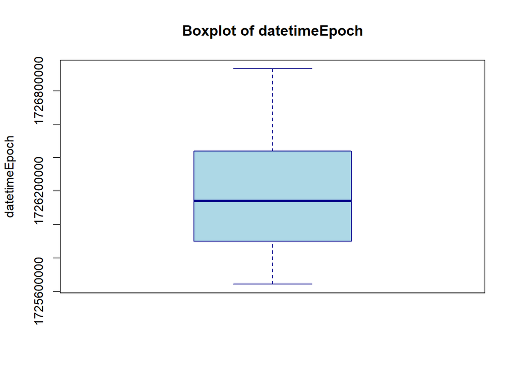

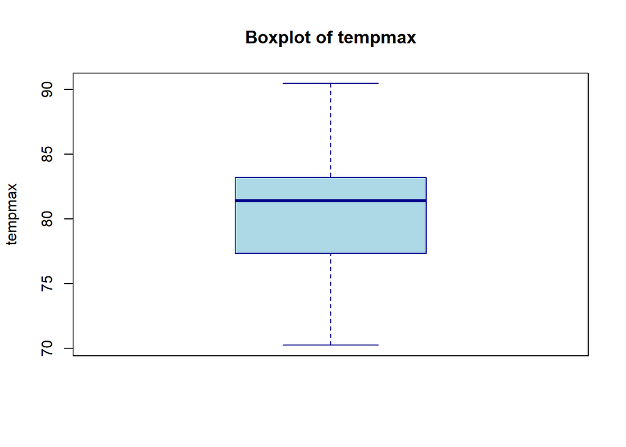

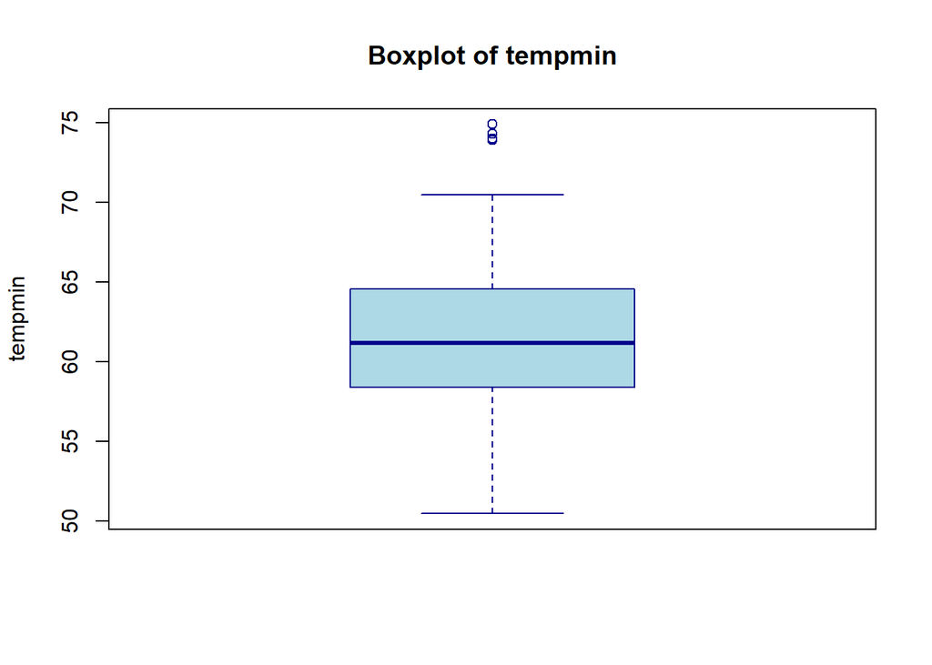

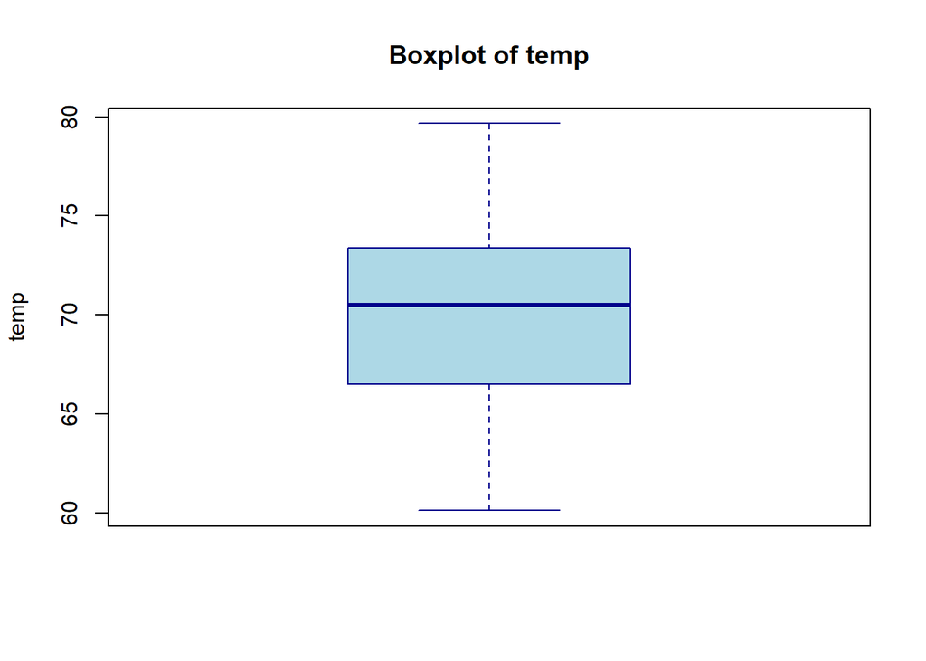

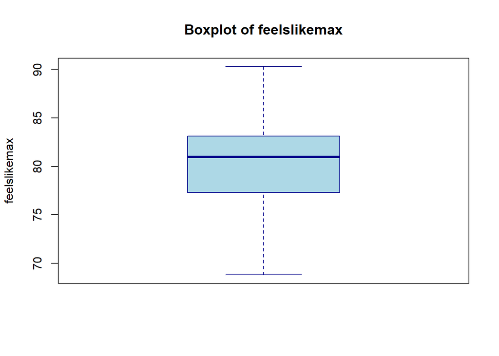

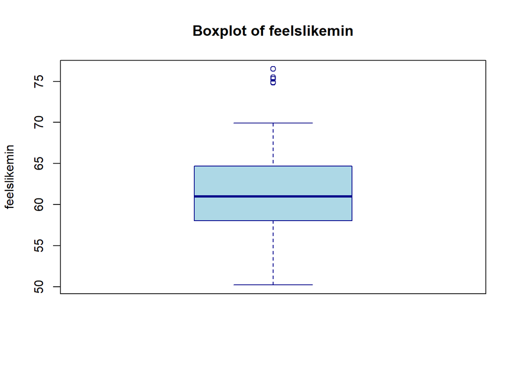

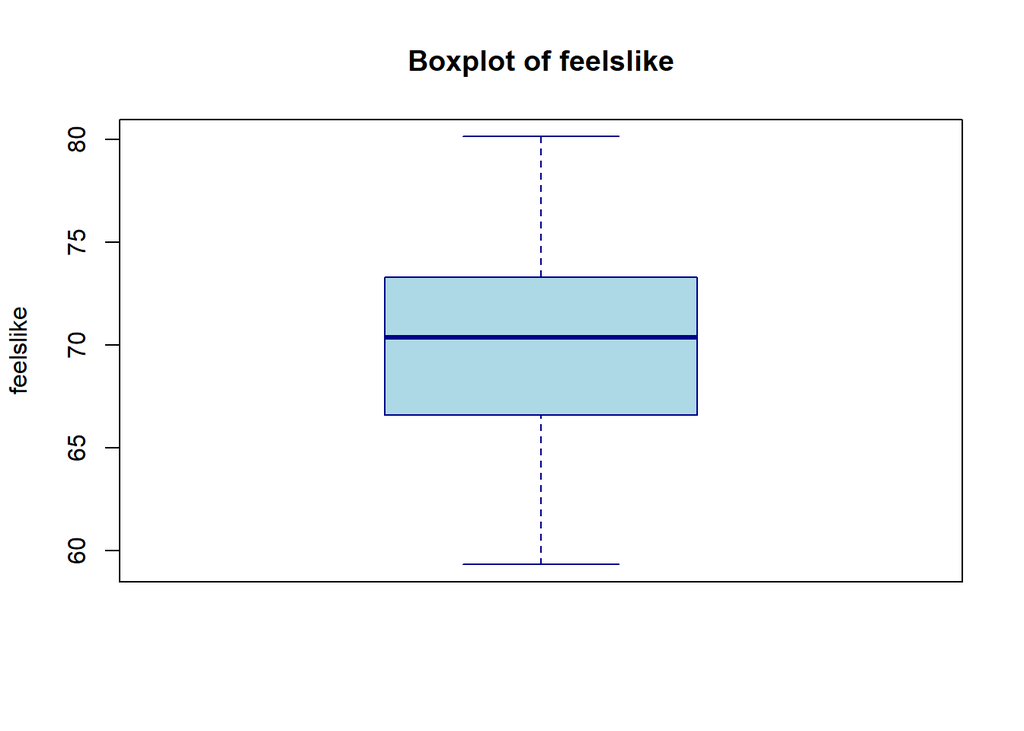

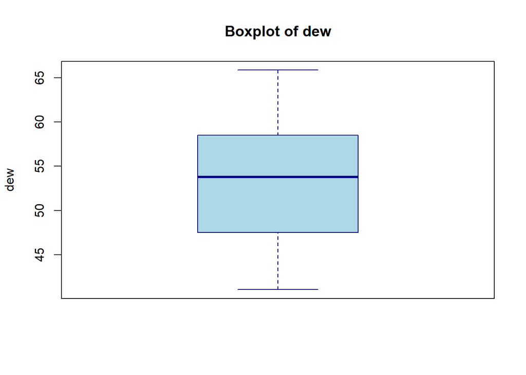

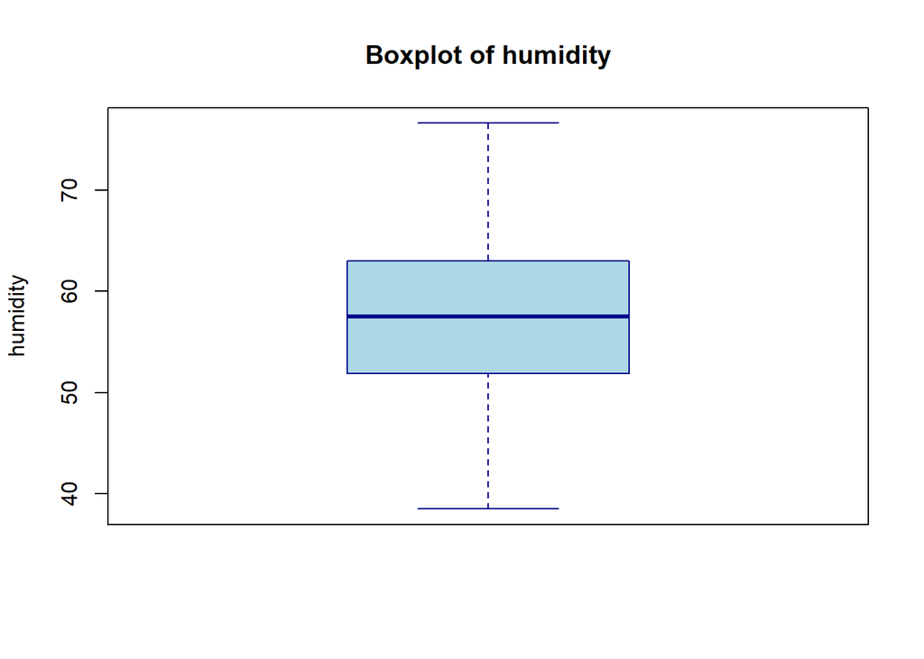

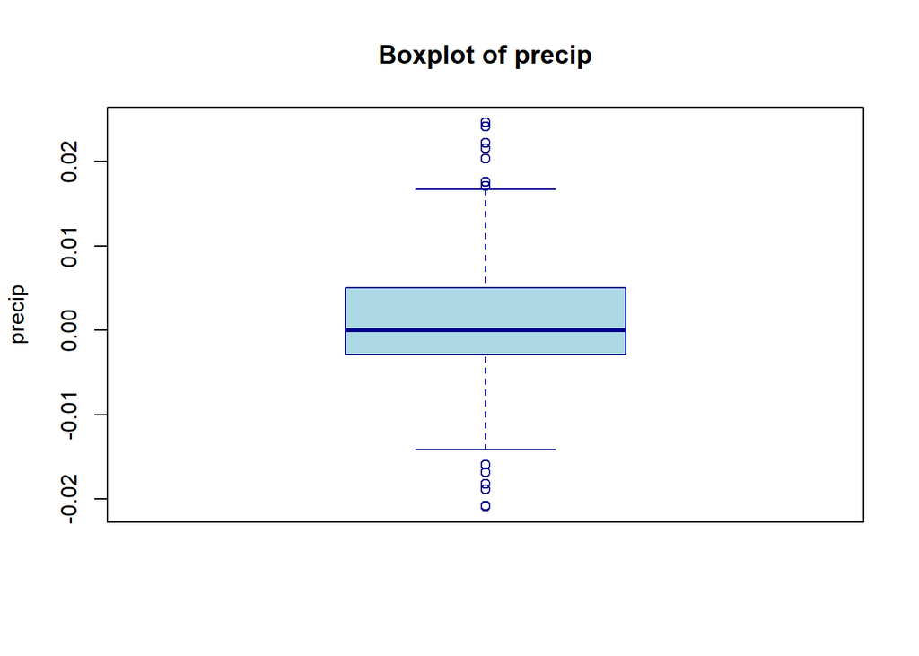

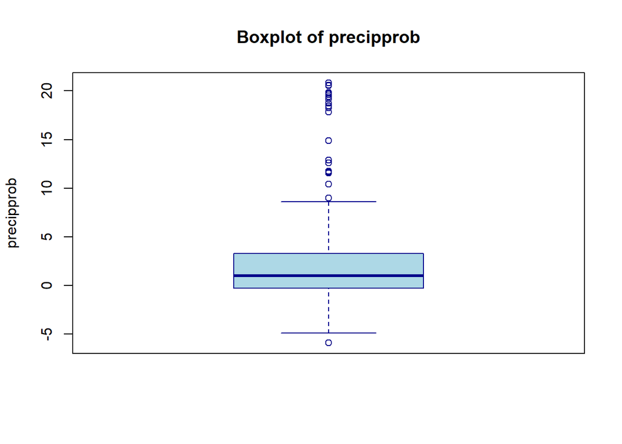

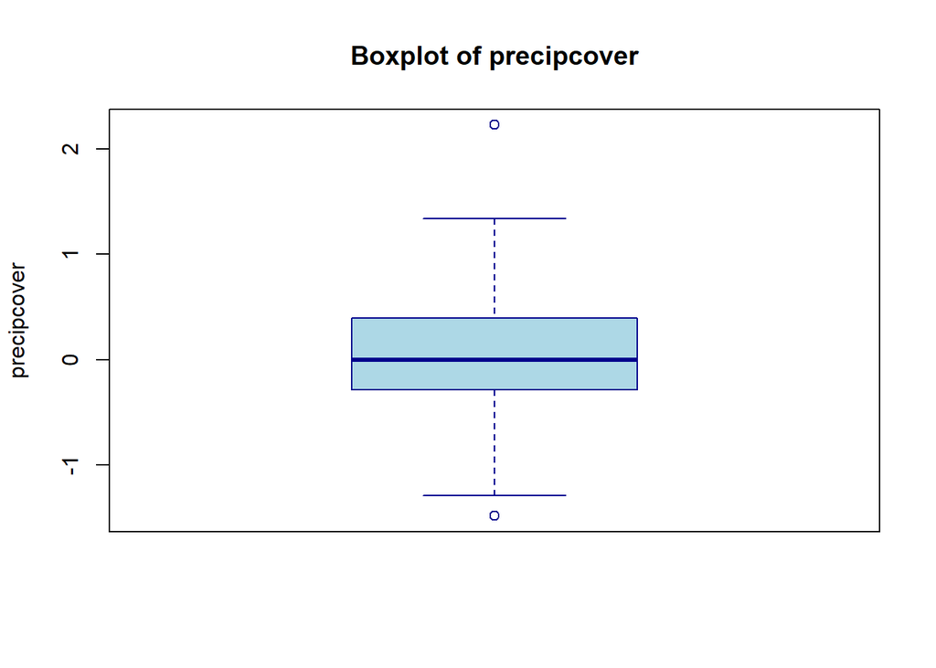

[17 more figures not shown]

```
##     datetime datetimeEpoch tempmax tempmin temp feelslikemax feelslikemin
## 1 07-09-2024    1725692400    89.0    62.1 73.3         88.6         62.1
## 3 10-09-2024    1725951600    79.4    59.6 67.8         79.4         59.6
## 5 12-09-2024    1726124400    79.2    57.8 67.4         79.2         57.8
## 6 13-09-2024    1726210800    83.2    58.9 69.6         82.2         58.9
## 7 14-09-2024    1726297200    81.4    59.4 68.8         81.3         59.4
## 8 15-09-2024    1726383600    78.3    59.8 66.8         78.3         59.8
##   feelslike  dew humidity precip precipprob precipcover windgust windspeed
## 1      73.3 59.8     66.3      0        0.0           0     16.1       9.2
## 3      67.8 57.2     70.7      0        0.0           0     17.4       9.8
## 5      67.4 55.6     68.3      0        5.0           0     17.9      10.7
## 6      69.5 54.2     60.5      0        0.0           0     16.1       8.9
## 7      68.8 55.5     64.2      0        1.0           0     16.6       9.8
## 8      66.8 47.3     52.9      0        3.2           0      9.8       8.9
##   winddir pressure cloudcover visibility solarradiation solarenergy uvindex
```

[output cut: 27 more lines]

```
## [1] "Row Count: 18885 Column Count: 39"
```

4.5 Univariate Analysis

Most of the population has health risk scores around 9.0, with a small subset showing elevated scores near 10.0.

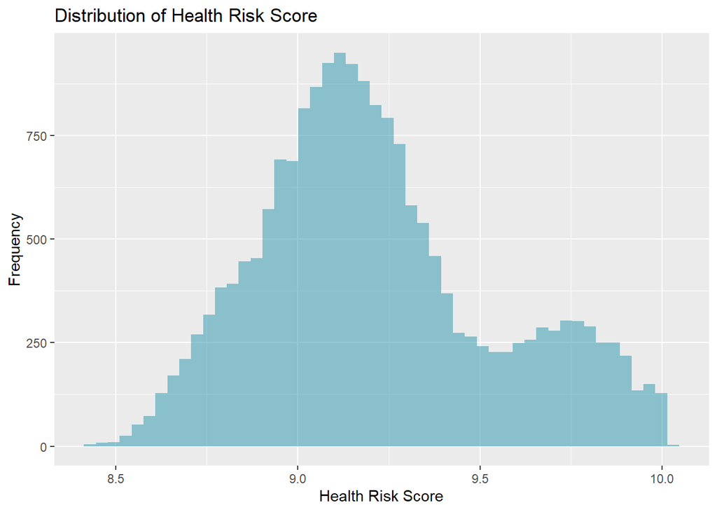

```
## [1] "The majority of the population has health risk scores around 9.0, with a small subset showing elevated scores near 10.0."
```

4.6 Bivariate and Multivariate Analysis

There is a significant difference in Health Risk Scores between weekends and weekdays. Scores are generally higher on weekends than on weekdays, indicating increased health risks during weekends

```
## [1] "Is there a statistically significant difference in the Health Risk Score on weekends compared to weekdays?"
```

```
## Hypothesis Statements:
```

```
## Null Hypothesis (H0): There is no significant difference in the Health Risk Score between weekends and weekdays.
```

```
## Alternative Hypothesis (H1): There is a significant difference in the Health Risk Score between weekends and weekdays.
```

```
##
##  Welch Two Sample t-test
##
## data:  weekend_scores and weekday_scores
## t = 29.51, df = 5925, p-value <2e-16
## alternative hypothesis: true difference in means is not equal to 0
## 95 percent confidence interval:
##  0.175105 0.200027
## sample estimates:
## mean of x mean of y
##   9.36019   9.17262
```

```
##
## Interpretation:
```

```
## Reject the null hypothesis: There is a statistically significant difference in the Health Risk Score between weekends and weekdays.
```

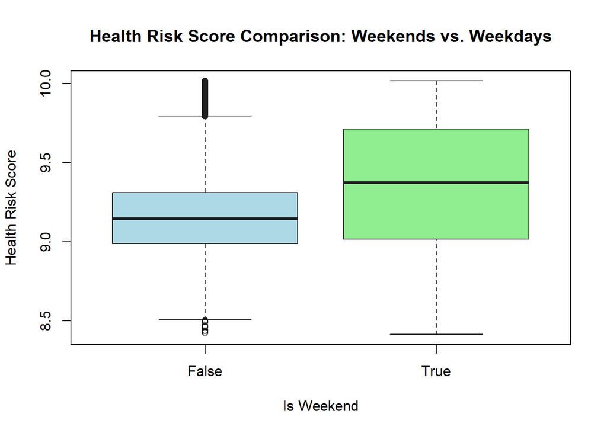

```
## [1] "The weak negative correlation of -0.24 suggests that higher temperatures are slightly associated with lower health risk scores, though the relationship is not strong"
```

San Jose has the highest health risk score and wind gusts, while Philadelphia shows the lowest health risk score and Los Angeles the lowest wind gusts.

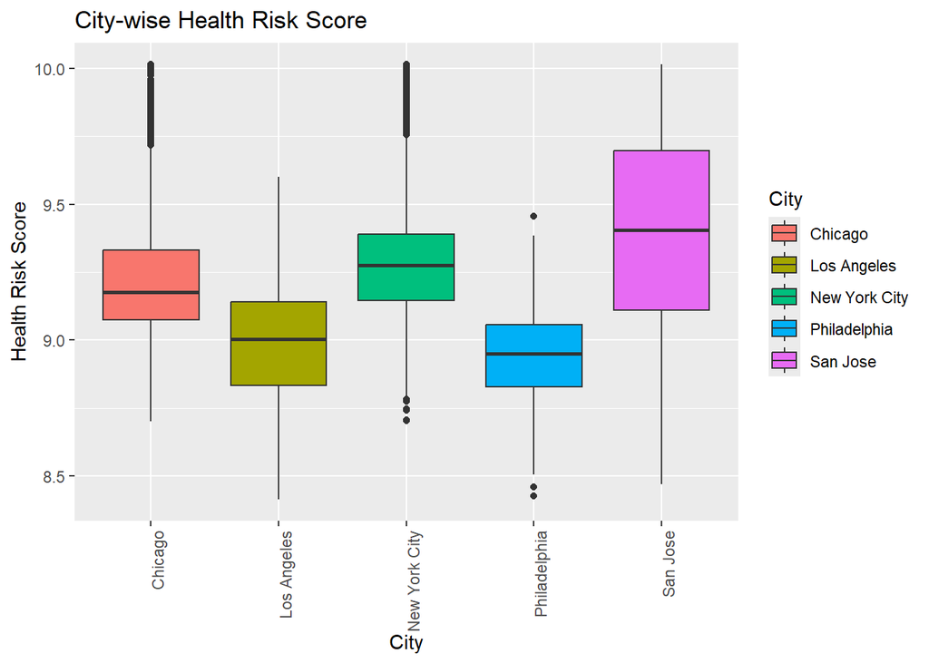

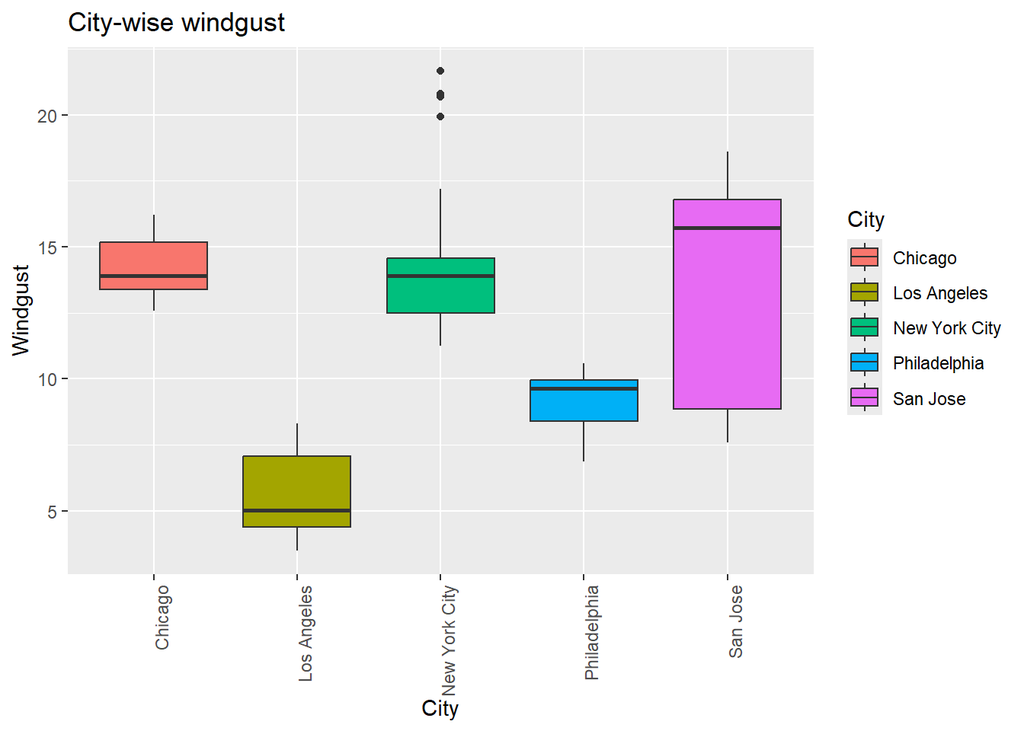

Visualize the strength and direction of relationships (correlations) between pairs of variables in a dataset.

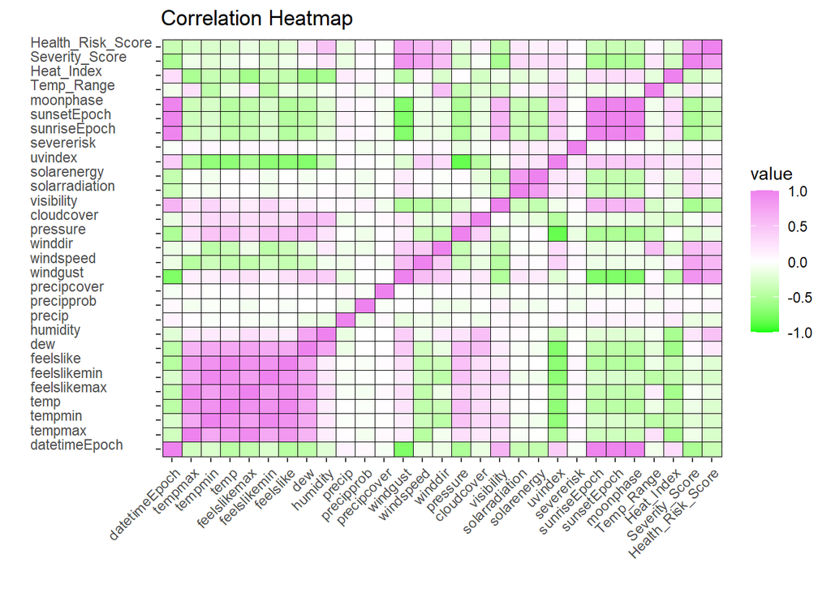

Wind gusts have a positive impact on health risk, whereas temperature has a weaker, slightly negative relationship with health risk scores.Wind-related factors (gusts and speed) and humidity increase health risk scores, while factors like visibility, sunrise/sunset times, and moon phases reduce them.

```
## [1] "Does wind gust have a significant impact on the Health Risk Score?"
```

```
## [1] "Correlation between windgust and Health risk : 0.719211489784875"
```

```
## [1] "Correlation between severity score and Health risk : 0.798129427599938"
```

```
## [1] "Correlation between wind speed and Health risk : 0.586553375240776"
```

```
## [1] "Correlation between humidity and Health risk : 0.505210350812955"
```

[output not shown]

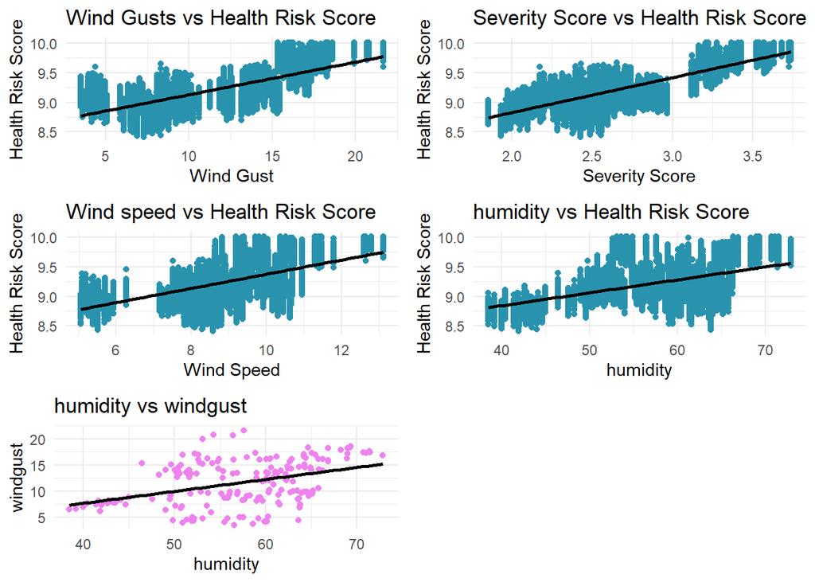

[output not shown]

[output not shown]

[output not shown]

[output not shown]

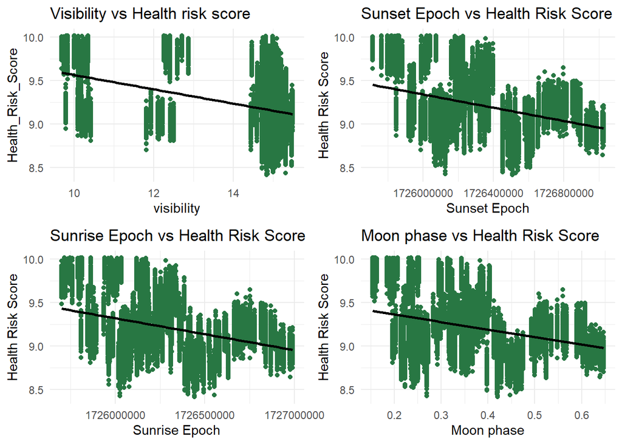

```
## # A tibble: 5 × 6
##   City    Avg_Dew_Point Avg_Humidity Avg_Pressure Total_Precipitation pressure_a
##   <fct>           <dbl>        <dbl>        <dbl>               <dbl>      <dbl>
## 1 Chicago          52.4         52.2        1018.               1.45    3391525.
## 2 Los An…          45.8         50.6        1012.              10.2     3678768.
## 3 New Yo…          57.0         60.6        1021.               0.232   3590429.
## 4 Philad…          59.0         63.2        1022.               2.99    2374491.
## 5 San Jo…          51.9         59.3        1010.              -1.52    6143571.
```

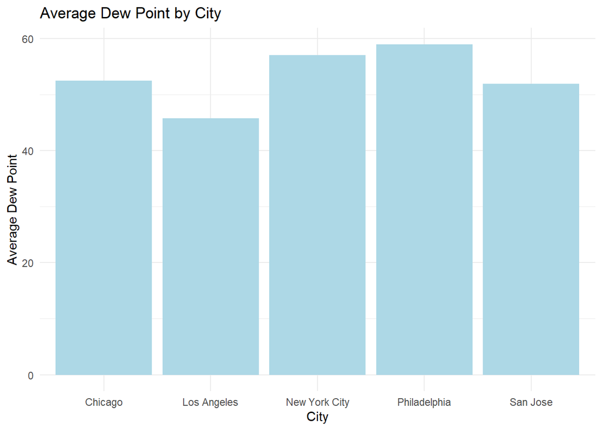

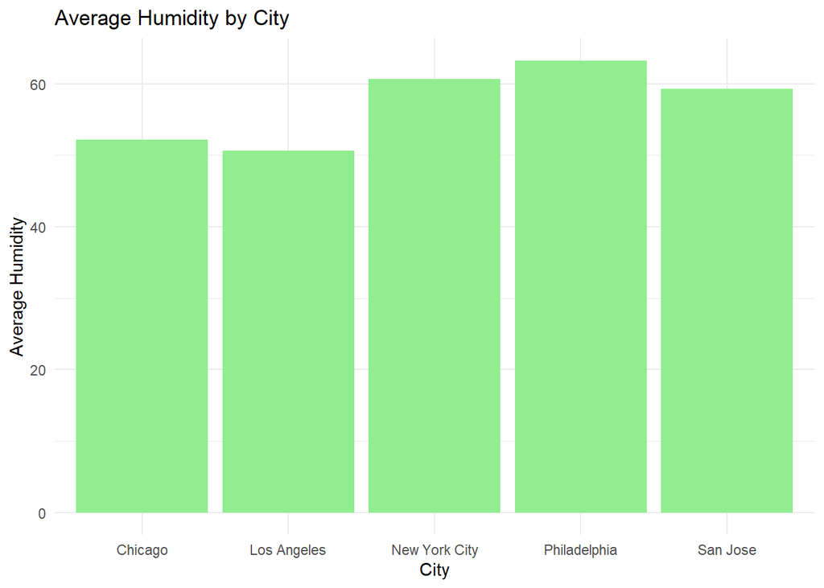

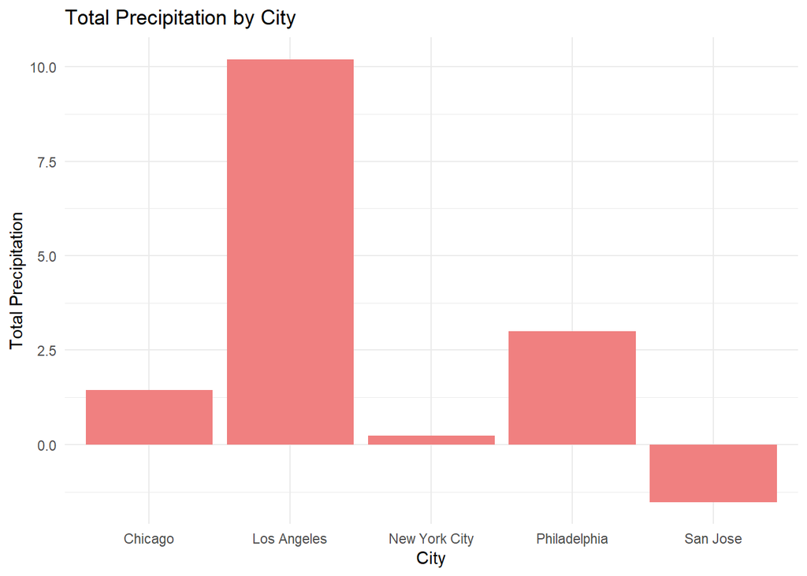

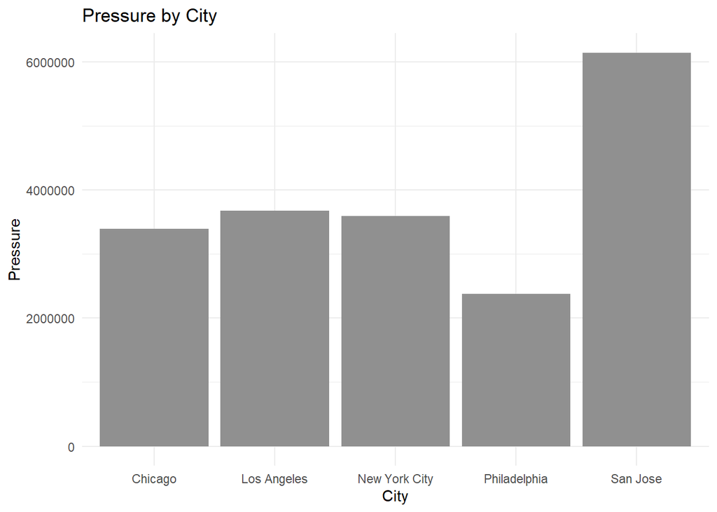

Both health risk and wind gust scores fluctuate similarly over time, peaking around September 8th and declining sharply by mid- September. Health risk score is being influenced by windgust.

```
## [1] "How does the windgust vary over dates?"
```

```
## # A tibble: 6 × 2
##   datetime   Average_HRS
##   <date>           <dbl>
## 1 2024-09-07        15.9
## 2 2024-09-08        17.5
## 3 2024-09-09        15.6
## 4 2024-09-10        15.2
## 5 2024-09-11        11.2
## 6 2024-09-12        13.4
```

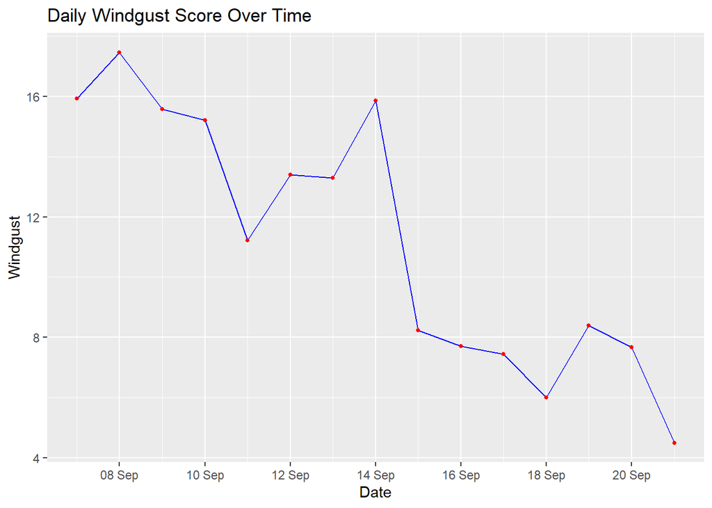

```
## [1] "How does the Health Risk Score vary over dates?"
```

```
## # A tibble: 6 × 2
##   datetime   Average_HRS
##   <date>           <dbl>
## 1 2024-09-07        9.83
## 2 2024-09-08        9.80
## 3 2024-09-09        9.22
## 4 2024-09-10        9.42
## 5 2024-09-11        9.01
## 6 2024-09-12        9.30
```

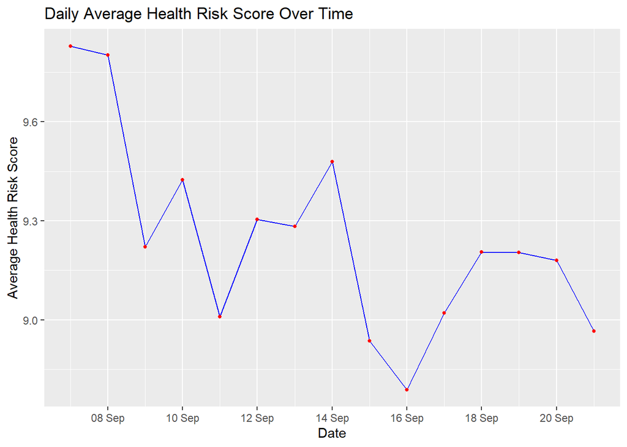

```
## # A tibble: 6 × 3
## # Groups:   City [2]
##   City        datetime   Average_HRS
##   <fct>       <date>           <dbl>
## 1 Chicago     2024-09-08        9.75
## 2 Chicago     2024-09-09        9.14
## 3 Chicago     2024-09-10        9.06
## 4 Chicago     2024-09-11        9.15
## 5 Chicago     2024-09-12        9.26
## 6 Los Angeles 2024-09-15        8.72
```

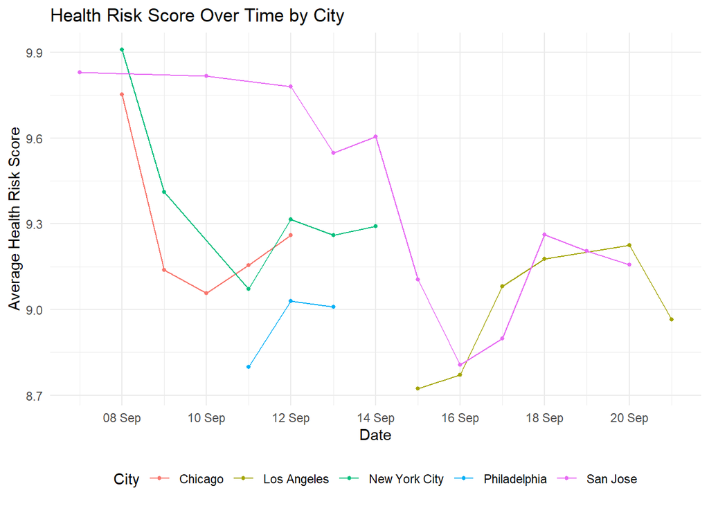

5. Conclusion and EDA Insights

Health Risk Variation: Health risk scores are higher on weekends compared to weekdays, indicating greater risks during weekends.

City Comparison: San Jose has the highest health risk and wind gusts, while Philadelphia shows the lowest health risk.

Meteorological Impact: Wind gusts significantly increase health risk scores, while temperature has a weaker influence.

Humidity and Health: Health risk scores fluctuate with changes in wind gusts, peaking in early September.

Key Factors: Wind-related factors increase health risks, while visibility and sunrise/sunset times lowers them indirectly.

6. Further Research and Limitations